# Trabajo_final_Rosello

Ignacia Rosello

2026-06-19

# Diversidad de ectomicorrizas mediada por el muérdago *Desmaria mutabilis* en un bosque de *Nothofagus* de alta montaña

Se trabajará con una matriz de datos simulada, buscando representar los datos que serían obtenidos a partir del siguiente diseño experimental:

# Pregunta de investigación

**¿Modifica la presencia del muérdago *Desmaria mutabilis* en bosques de *Nothofagus pumilio* de alta montaña la composición y la diversidad de las comunidades de hongos ectomicorrícicos en la rizósfera de *N. pumilio*?**

El sitio de estudio es el bosque de *Nothofagus* de alta montaña en el Parque Nacional Nahuelbuta, ubicado en la zona más elevada de la cordillera de Nahuelbuta, en la Provincia de Malleco, región de la Araucanía, Chile (37°78’S 72°36’W). Se identificaron 20 individuos de *Nothofagus pumilio* (familia Nothofagaceae) que presentaran infección por *Desmaria mutabilis*, un muérdago hemiparásito de la familia Loranthaceae, y 20 individuos con ausencia de infección, cumpliendo con criterios de distancia suficiente para garantizar independencia y evitar la pseudorreplicación espacial. Para cada individuo de *N. pumilio* se colectó una muestra de rizósfera, sumando un total de 20 muestras de rizósfera provenientes de individuos hospederos (infectados por *D. mutabilis*) y 20 muestras provenientes de individuos no infectados.

Se extrajo ADN de las muestras de rizósfera para ser secuenciadas por *metabarcoding* de la región ITS2 para determinar y comparar la composición taxonómica de las comunidades de hongos ectomicorrícicos (HECM) en la rizósfera de individuos de *N. pumilio* en presencia y en ausencia de infección por el muérdago *D. mutabilis*. Los datos obtenidos fueron procesados y se obtuvo una tabla de abundancia por especie según presencia o ausencia de *D. mutabilis*. Por tanto, el presente estudio tiene como hipótesis y objetivos:

# Hipótesis

**Dado que los muérdagos producen hojarasca rica en nutrientes, la presencia del muérdago *Desmaria mutabilis* en bosques de *Nothofagus pumilio* de alta montaña modifica la composición y la diversidad de las comunidades de hongos ectomicorrícicos en la rizósfera de *N. pumilio*. Por tanto, los sitios con presencia de D. mutabilis presentarán una composición diferente y una mayor diversidad de hongos ectomicorrícicos en comparación con los sitios sin muérdago.**

# Objetivo general

**Determinar el efecto de la presencia del muérdago *Desmaria mutabilis* sobre la composición y la diversidad de las comunidades de hongos ectomicorrícicos en la rizósfera de *Nothofagus pumilio* en bosques de *N. pumilio* de alta montaña.**

# Objetivos específicos

**1. Caracterizar las comunidades de hongos ectomicorrícicos en la rizósfera de *Nothofagus pumilio* en individuos infectados y no infectados por *D. mutabilis*.**

**2. Evaluar las diferencias en la composición y la diversidad de las comunidades de hongos ectomicorrícicos entre individuos infectados y no infectados por *D. mutabilis*.**

# Variables

**Variable independiente:** Presencia del muérdago *Desmaria mutabilis* (presencia/ausencia de *D. mutabilis*) **Variable dependiente:** Riqueza y abundancia de especies de hongos ectomicorrícicos.

#——————————————————————————-

## OE1. Caracterizar las comunidades de hongos ectomicorrícicos en la rizósfera de *Nothofagus pumilio* para individuos infectados y no infectados por *D. mutabilis*

# 1. Generación de datos simulados

La matriz de abundancia de hongos ectomicorrícicos pseudorrealista (realista pero manejable en magnitud) simulando las tablas de abundancia obtenidas a partir del procesamiento de los datos obtenidos en la secuenciación fue generada mediante código R desarrollado con asistencia de un modelo de lenguaje de inteligencia artificial (Perplexity AI, Junio 2026). El código fue diseñado específicamente para replicar características pseudorrealistas de riqueza, abundancia y evenness basadas en datos de metabarcoding ITS2 de rizósfera en bosques de Nothofagus, siguiendo el *workflow* descrito por Saona et al. (2025).

```r
set.seed(42)

# Parámetros
n_samples <- 40
n_sp <- 35  # número de ASVs/especies HECM

sp_names <- paste0("sp", sprintf("%02d", 1:n_sp))

# Grupos: 20 con presencia, 20 con ausencia de D. mutabilis
presencia_vec <- c(rep("presencia", 20), rep("ausencia", 20))

# Parámetros de abundancia por grupo
# Con muérdago: más riqueza, mayor abundancia, distribución más equitativa
# Sin muérdago: menos riqueza, dominancia por pocas especies (menor evenness)

generate_sample <- function(group, n_sp) {
  if (group == "presencia") {
    # Alta riqueza: ~22-30 especies presentes por muestra
    n_present <- sample(22:30, 1)
    present_sp <- sample(1:n_sp, n_present)
    # Distribución log-normal moderada (más evenness)
    counts <- rep(0, n_sp)
    counts[present_sp] <- round(rlnorm(n_present, meanlog = 2.5, sdlog = 1.2))
  } else {
    # Baja riqueza: ~8-16 especies presentes
    n_present <- sample(8:16, 1)
    present_sp <- sample(1:n_sp, n_present)
    # Mayor dominancia: pocos taxa con muchas lecturas, resto muy bajo
    counts <- rep(0, n_sp)
    raw <- round(rlnorm(n_present, meanlog = 2.0, sdlog = 1.5))
    # Amplifica dominantes
    dominants <- order(raw, decreasing = TRUE)[1:3]
    raw[dominants] <- raw[dominants] * sample(2:3, 3, replace = TRUE)
    counts[present_sp] <- raw
  }
  return(counts)
}

# --- Construir matriz ---
abundance_matrix <- t(sapply(presencia_vec, generate_sample, n_sp = n_sp))
colnames(abundance_matrix) <- sp_names

# Armar data frame final
df_wide <- data.frame(
  D_mutabilis = presencia_vec,
  abundance_matrix,
  check.names = FALSE,
  row.names = NULL   # ← elimina los rownames automáticos

)

# Vista previa
head(df_wide[, 1:8])
```

```
##   D_mutabilis sp01 sp02 sp03 sp04 sp05 sp06 sp07
## 1   presencia   39    0  154   39    8    0   19
## 2   presencia    0   31   17    4   14    0    1
## 3   presencia    4    2    0    0    0    7    0
## 4   presencia    4    0   11   61   72    9   27
## 5   presencia   20   72    7  144    8   14    9
## 6   presencia    4   54    4    3   74   28  101
```

```r
dim(df_wide)
```

```
## [1] 40 36
```

```r
# --- Verificación rápida de Shannon ---
library(vegan)

H <- diversity(abundance_matrix, index = "shannon")
df_check <- data.frame(D_mutabilis = presencia_vec, Shannon = H)

tapply(df_check$Shannon, df_check$D_mutabilis, mean)
```

```
##  ausencia presencia
##  1.494440  2.629499
```

```r
# Debería mostrar H más alto en "presencia" que en "ausencia"

# Exportar en formato .csv (remover # si se desea exportar)
#write.csv(df_wide, "fake_hhecm_data.csv", row.names = FALSE)
```

## 2. Evaluar las diferencias en la diversidad de las comunidades de hongos ectomicorrícicos entre individuos infectados y no infectados por *D. mutabilis*

# 2. Análisis exploratorio de los datos

Tras responder al OE1 al haber generado la matriz de datos simulados se comienza con la exploración de los datos. A continuación, se ejecitan algunas funciones básicas y plots exploratorios pertinentes para conocer la estructura y obtener una aproximación a su distribución.

```r
#Estructura y contenido de los datos

datah <- df_wide #Solo para hacer el data.frame más rápido y amigable de llamar

attach(datah)
str(datah)
```

```
## 'data.frame':    40 obs. of  36 variables:
##  $ D_mutabilis: chr  "presencia" "presencia" "presencia" "presencia" ...
##  $ sp01       : num  39 0 4 4 20 4 0 27 27 22 ...
##  $ sp02       : num  0 31 2 0 72 54 5 9 4 4 ...
##  $ sp03       : num  154 17 0 11 7 4 5 3 22 0 ...
##  $ sp04       : num  39 4 0 61 144 3 293 0 4 47 ...
##  $ sp05       : num  8 14 0 72 8 74 0 0 8 0 ...
##  $ sp06       : num  0 0 7 9 14 28 24 25 13 0 ...
##  $ sp07       : num  19 1 0 27 9 101 11 0 10 4 ...
##  $ sp08       : num  0 30 0 0 10 7 11 51 9 0 ...
##  $ sp09       : num  15 38 14 0 22 13 7 14 0 3 ...
##  $ sp10       : num  22 0 14 41 2 35 13 2 16 5 ...
##  $ sp11       : num  0 25 6 0 14 0 67 7 3 10 ...
##  $ sp12       : num  0 16 2 72 3 0 4 62 37 11 ...
##  $ sp13       : num  3 0 1 7 0 3 5 29 22 0 ...
```

[output cut: 22 more lines]

```r
head(datah)
```

```
##   D_mutabilis sp01 sp02 sp03 sp04 sp05 sp06 sp07 sp08 sp09 sp10 sp11 sp12 sp13
## 1   presencia   39    0  154   39    8    0   19    0   15   22    0    0    3
## 2   presencia    0   31   17    4   14    0    1   30   38    0   25   16    0
## 3   presencia    4    2    0    0    0    7    0    0   14   14    6    2    1
## 4   presencia    4    0   11   61   72    9   27    0    0   41    0   72    7
## 5   presencia   20   72    7  144    8   14    9   10   22    2   14    3    0
## 6   presencia    4   54    4    3   74   28  101    7   13   35    0    0    3
##   sp14 sp15 sp16 sp17 sp18 sp19 sp20 sp21 sp22 sp23 sp24 sp25 sp26 sp27 sp28
## 1   31  124    0   10    5    0   27    0    5    0   96   35   17   38   13
## 2   18   21   77   83   36   14    9    9    7    9    3    2    4    0    7
## 3    3  312   12    0   24    7    7   69    7    2   47   12   15    0    0
## 4   15   20   75    0    7  141    8    9    0    6  206    0    4    8    2
## 5    3   11    0    6    3    1    0   50    3   25    0    5  108    3   18
## 6    7    9    6    5   29   12    4   66    7    3    5   22    6    5    5
##   sp29 sp30 sp31 sp32 sp33 sp34 sp35
## 1    0    0    4   18    0    4    0
## 2    9    3    0    4    8  103   16
## 3    8   12   15   14    7   14    2
## 4    0    7    0    6    0    2    2
## 5    0   10   13   23   10   19  140
## 6    1    0   15   19    0    0    7
```

```r
dim(datah)
```

```
## [1] 40 36
```

```r
summary(datah)
```

```
##  D_mutabilis             sp01            sp02             sp03
##  Length:40          Min.   : 0.00   Min.   :  0.00   Min.   :  0.00
##  Class :character   1st Qu.: 0.00   1st Qu.:  0.00   1st Qu.:  0.00
##  Mode  :character   Median : 4.00   Median :  1.50   Median :  4.50
##                     Mean   :12.10   Mean   : 21.88   Mean   : 17.52
##                     3rd Qu.:14.75   3rd Qu.: 15.50   3rd Qu.: 16.00
##                     Max.   :91.00   Max.   :345.00   Max.   :208.00
##       sp04             sp05            sp06             sp07
##  Min.   :  0.00   Min.   :  0.0   Min.   :  0.00   Min.   :  0.00
##  1st Qu.:  0.00   1st Qu.:  0.0   1st Qu.:  0.00   1st Qu.:  0.00
##  Median :  1.50   Median :  3.5   Median :  0.00   Median :  1.00
##  Mean   : 26.45   Mean   : 19.9   Mean   : 22.50   Mean   : 10.68
##  3rd Qu.: 15.00   3rd Qu.: 17.5   3rd Qu.: 12.25   3rd Qu.: 10.25
##  Max.   :293.00   Max.   :168.0   Max.   :531.00   Max.   :101.00
##       sp08            sp09             sp10             sp11
##  Min.   : 0.00   Min.   :  0.00   Min.   :  0.00   Min.   :  0.00
##  1st Qu.: 0.00   1st Qu.:  0.00   1st Qu.:  0.00   1st Qu.:  0.00
##  Median : 2.50   Median :  2.50   Median :  3.00   Median :  3.00
##  Mean   : 9.60   Mean   : 10.22   Mean   : 17.02   Mean   : 19.95
##  3rd Qu.:10.25   3rd Qu.: 13.25   3rd Qu.: 16.75   3rd Qu.: 14.00
##  Max.   :87.00   Max.   :144.00   Max.   :168.00   Max.   :260.00
##       sp12             sp13             sp14            sp15
##  Min.   :   0.0   Min.   :  0.00   Min.   : 0.00   Min.   :  0.00
##  1st Qu.:   0.0   1st Qu.:  0.00   1st Qu.: 0.00   1st Qu.:  0.00
##  Median :   3.5   Median :  1.00   Median : 3.00   Median :  4.00
##  Mean   : 119.4   Mean   : 17.45   Mean   :13.38   Mean   : 31.23
##  3rd Qu.:  18.5   3rd Qu.:  8.00   3rd Qu.:15.25   3rd Qu.: 20.25
##  Max.   :4194.0   Max.   :466.00   Max.   :98.00   Max.   :312.00
##       sp16             sp17             sp18             sp19
##  Min.   :  0.00   Min.   :  0.00   Min.   :  0.00   Min.   :  0.00
##  1st Qu.:  0.00   1st Qu.:  0.00   1st Qu.:  0.00   1st Qu.:  0.00
##  Median :  2.00   Median :  2.50   Median :  3.00   Median :  3.00
##  Mean   : 15.78   Mean   : 17.12   Mean   : 17.20   Mean   : 22.40
##  3rd Qu.: 13.25   3rd Qu.: 10.50   3rd Qu.: 14.25   3rd Qu.: 17.75
##  Max.   :136.00   Max.   :261.00   Max.   :142.00   Max.   :218.00
##       sp20             sp21            sp22             sp23
##  Min.   :  0.00   Min.   : 0.00   Min.   :  0.00   Min.   :  0.00
##  1st Qu.:  0.00   1st Qu.: 0.00   1st Qu.:  0.00   1st Qu.:  0.00
##  Median :  2.00   Median : 0.50   Median :  1.00   Median :  3.00
##  Mean   : 21.88   Mean   :10.62   Mean   : 14.38   Mean   : 26.75
```

[output cut: 8 more lines]

```
##  Max.   :206.00   Max.   :394.00   Max.   :108.00   Max.   :156.00
##       sp28             sp29            sp30             sp31
##  Min.   :  0.00   Min.   :  0.0   Min.   :  0.00   Min.   : 0.00
##  1st Qu.:  0.00   1st Qu.:  0.0   1st Qu.:  0.00   1st Qu.: 0.00
##  Median :  2.50   Median :  2.0   Median :  1.00   Median : 1.00
##  Mean   : 12.82   Mean   : 17.3   Mean   : 12.75   Mean   : 5.95
##  3rd Qu.: 12.00   3rd Qu.: 13.0   3rd Qu.: 12.50   3rd Qu.: 7.75
##  Max.   :218.00   Max.   :176.0   Max.   :162.00   Max.   :58.00
##       sp32             sp33             sp34             sp35
##  Min.   :  0.00   Min.   :  0.00   Min.   :  0.00   Min.   :  0.00
##  1st Qu.:  0.00   1st Qu.:  0.00   1st Qu.:  0.00   1st Qu.:  0.00
##  Median :  3.50   Median :  0.00   Median :  2.00   Median :  1.50
##  Mean   : 18.05   Mean   :  9.65   Mean   : 12.15   Mean   : 25.18
##  3rd Qu.: 15.00   3rd Qu.:  7.00   3rd Qu.: 14.00   3rd Qu.: 16.00
##  Max.   :373.00   Max.   :133.00   Max.   :108.00   Max.   :318.00
```

Entonces, para explorar los valores numéricos:

```r
datan <- datah[, -1]

#Para confirmar:
dim(datan)
```

```
## [1] 40 35
```

```r
sapply(datan, is.numeric)
```

```
## sp01 sp02 sp03 sp04 sp05 sp06 sp07 sp08 sp09 sp10 sp11 sp12 sp13 sp14 sp15 sp16
## TRUE TRUE TRUE TRUE TRUE TRUE TRUE TRUE TRUE TRUE TRUE TRUE TRUE TRUE TRUE TRUE
## sp17 sp18 sp19 sp20 sp21 sp22 sp23 sp24 sp25 sp26 sp27 sp28 sp29 sp30 sp31 sp32
## TRUE TRUE TRUE TRUE TRUE TRUE TRUE TRUE TRUE TRUE TRUE TRUE TRUE TRUE TRUE TRUE
## sp33 sp34 sp35
## TRUE TRUE TRUE
```

```r
#Distribución por condición (presencia/ausencia de D. mutabilis)
table(datah$D_mutabilis)
```

```
##
##  ausencia presencia
##        20        20
```

```r
sum(datan)
```

```
## [1] 27621
```

```r
colSums(datan)
```

```
## sp01 sp02 sp03 sp04 sp05 sp06 sp07 sp08 sp09 sp10 sp11 sp12 sp13 sp14 sp15 sp16
##  484  875  701 1058  796  900  427  384  409  681  798 4775  698  535 1249  631
## sp17 sp18 sp19 sp20 sp21 sp22 sp23 sp24 sp25 sp26 sp27 sp28 sp29 sp30 sp31 sp32
##  685  688  896  875  425  575 1070  853  642  403  554  513  692  510  238  722
## sp33 sp34 sp35
##  386  486 1007
```

```r
rowSums(datan)
```

```
##  [1]  726  618  639  822  776  559  660  413  642  652  451  566  815  668  476
## [16]  515 1486 1057  467  621  813  690 4564  248  289  574  109  212  256  260
## [31] 1151  547  592  440  676  834  634  236  433  434
```

```r
summary(datan)
```

```
##       sp01            sp02             sp03             sp04
##  Min.   : 0.00   Min.   :  0.00   Min.   :  0.00   Min.   :  0.00
##  1st Qu.: 0.00   1st Qu.:  0.00   1st Qu.:  0.00   1st Qu.:  0.00
##  Median : 4.00   Median :  1.50   Median :  4.50   Median :  1.50
##  Mean   :12.10   Mean   : 21.88   Mean   : 17.52   Mean   : 26.45
##  3rd Qu.:14.75   3rd Qu.: 15.50   3rd Qu.: 16.00   3rd Qu.: 15.00
##  Max.   :91.00   Max.   :345.00   Max.   :208.00   Max.   :293.00
##       sp05            sp06             sp07             sp08
##  Min.   :  0.0   Min.   :  0.00   Min.   :  0.00   Min.   : 0.00
##  1st Qu.:  0.0   1st Qu.:  0.00   1st Qu.:  0.00   1st Qu.: 0.00
##  Median :  3.5   Median :  0.00   Median :  1.00   Median : 2.50
##  Mean   : 19.9   Mean   : 22.50   Mean   : 10.68   Mean   : 9.60
##  3rd Qu.: 17.5   3rd Qu.: 12.25   3rd Qu.: 10.25   3rd Qu.:10.25
##  Max.   :168.0   Max.   :531.00   Max.   :101.00   Max.   :87.00
##       sp09             sp10             sp11             sp12
##  Min.   :  0.00   Min.   :  0.00   Min.   :  0.00   Min.   :   0.0
##  1st Qu.:  0.00   1st Qu.:  0.00   1st Qu.:  0.00   1st Qu.:   0.0
##  Median :  2.50   Median :  3.00   Median :  3.00   Median :   3.5
##  Mean   : 10.22   Mean   : 17.02   Mean   : 19.95   Mean   : 119.4
##  3rd Qu.: 13.25   3rd Qu.: 16.75   3rd Qu.: 14.00   3rd Qu.:  18.5
##  Max.   :144.00   Max.   :168.00   Max.   :260.00   Max.   :4194.0
##       sp13             sp14            sp15             sp16
##  Min.   :  0.00   Min.   : 0.00   Min.   :  0.00   Min.   :  0.00
##  1st Qu.:  0.00   1st Qu.: 0.00   1st Qu.:  0.00   1st Qu.:  0.00
##  Median :  1.00   Median : 3.00   Median :  4.00   Median :  2.00
##  Mean   : 17.45   Mean   :13.38   Mean   : 31.23   Mean   : 15.78
##  3rd Qu.:  8.00   3rd Qu.:15.25   3rd Qu.: 20.25   3rd Qu.: 13.25
##  Max.   :466.00   Max.   :98.00   Max.   :312.00   Max.   :136.00
##       sp17             sp18             sp19             sp20
##  Min.   :  0.00   Min.   :  0.00   Min.   :  0.00   Min.   :  0.00
##  1st Qu.:  0.00   1st Qu.:  0.00   1st Qu.:  0.00   1st Qu.:  0.00
##  Median :  2.50   Median :  3.00   Median :  3.00   Median :  2.00
##  Mean   : 17.12   Mean   : 17.20   Mean   : 22.40   Mean   : 21.88
##  3rd Qu.: 10.50   3rd Qu.: 14.25   3rd Qu.: 17.75   3rd Qu.: 10.00
##  Max.   :261.00   Max.   :142.00   Max.   :218.00   Max.   :447.00
##       sp21            sp22             sp23             sp24
##  Min.   : 0.00   Min.   :  0.00   Min.   :  0.00   Min.   :  0.00
##  1st Qu.: 0.00   1st Qu.:  0.00   1st Qu.:  0.00   1st Qu.:  0.00
##  Median : 0.50   Median :  1.00   Median :  3.00   Median :  1.50
##  Mean   :10.62   Mean   : 14.38   Mean   : 26.75   Mean   : 21.32
```

[output cut: 8 more lines]

```
##  Max.   :394.00   Max.   :108.00   Max.   :156.00   Max.   :218.00
##       sp29            sp30             sp31            sp32
##  Min.   :  0.0   Min.   :  0.00   Min.   : 0.00   Min.   :  0.00
##  1st Qu.:  0.0   1st Qu.:  0.00   1st Qu.: 0.00   1st Qu.:  0.00
##  Median :  2.0   Median :  1.00   Median : 1.00   Median :  3.50
##  Mean   : 17.3   Mean   : 12.75   Mean   : 5.95   Mean   : 18.05
##  3rd Qu.: 13.0   3rd Qu.: 12.50   3rd Qu.: 7.75   3rd Qu.: 15.00
##  Max.   :176.0   Max.   :162.00   Max.   :58.00   Max.   :373.00
##       sp33             sp34             sp35
##  Min.   :  0.00   Min.   :  0.00   Min.   :  0.00
##  1st Qu.:  0.00   1st Qu.:  0.00   1st Qu.:  0.00
##  Median :  0.00   Median :  2.00   Median :  1.50
##  Mean   :  9.65   Mean   : 12.15   Mean   : 25.18
##  3rd Qu.:  7.00   3rd Qu.: 14.00   3rd Qu.: 16.00
##  Max.   :133.00   Max.   :108.00   Max.   :318.00
```

```r
# Abundancia total
tot_abundance <- colSums(datan)
summary(tot_abundance)
```

```
##    Min. 1st Qu.  Median    Mean 3rd Qu.    Max.
##   238.0   498.0   685.0   789.2   864.0  4775.0
```

```r
# Riqueza
richness <- rowSums(datan > 0)
print("Species richness summary:")
```

```
## [1] "Species richness summary:"
```

```r
summary(richness)
```

```
##    Min. 1st Qu.  Median    Mean 3rd Qu.    Max.
##    7.00   12.00   19.00   19.62   28.00   30.00
```

Ahora, para explorar visualmente mediante representaciones gráficas:

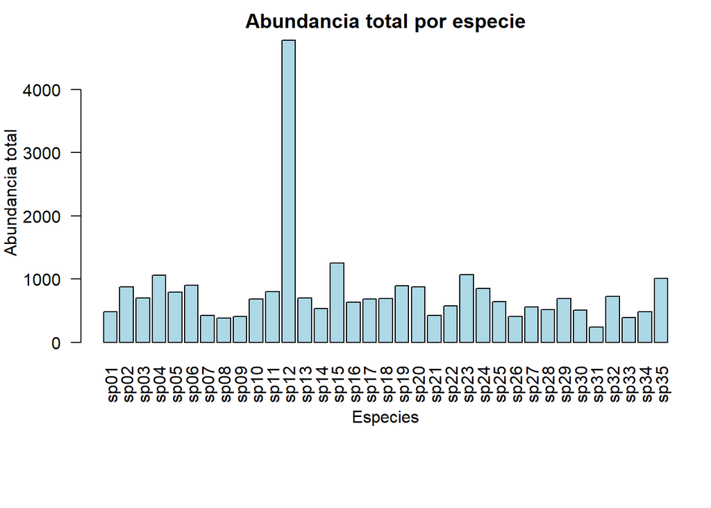

```r
#Distribución total de los datos

library(ggplot2)
library(dplyr)

par(mar=c(8,4,2,1))
barplot(colSums(datan), las=2, col="lightblue",
        main="Abundancia total por especie",
        ylab="Abundancia total",
        xlab= "Especies")
```

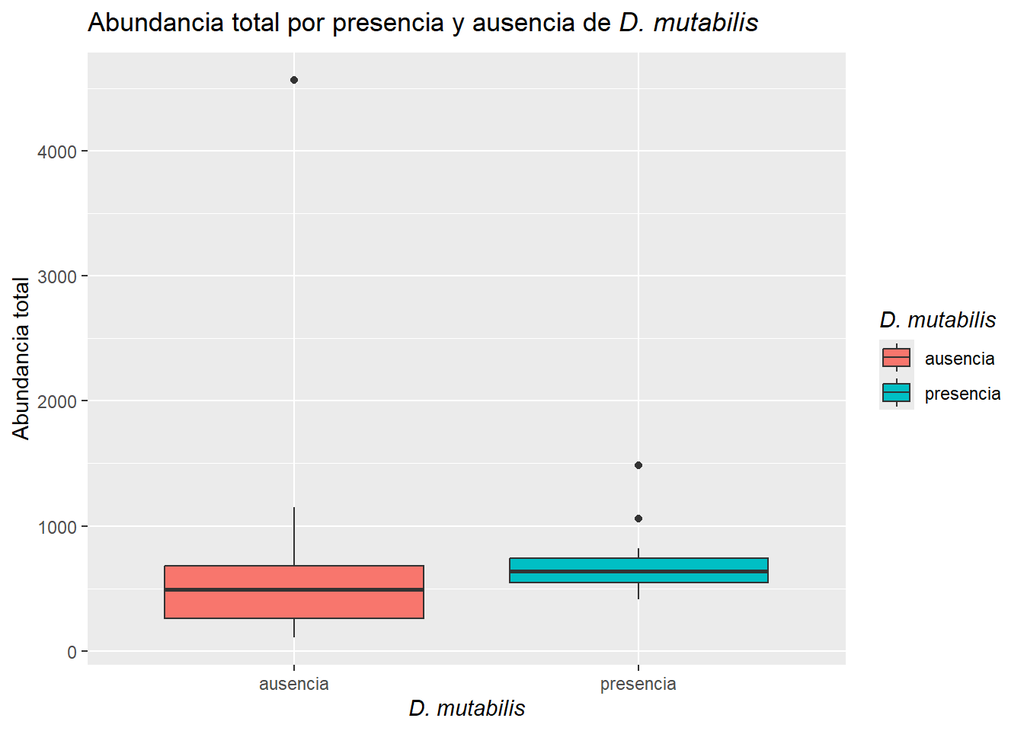

```r
# Abundancia total por muestra
df_wide <- df_wide %>%
  mutate(total = rowSums(across(starts_with("sp"))))

# Boxplot abundancia total por muestra
ggplot(df_wide, aes(x = D_mutabilis, y = total, fill = D_mutabilis)) +
  geom_boxplot() +
  labs(
    title = expression("Abundancia total por presencia y ausencia de " * italic("D. mutabilis")),
    x = expression(italic("D. mutabilis")),
    y = "Abundancia total",
    fill = expression(italic("D. mutabilis"))
  )
```

Luego de una primera aproximación a los datos, comenzamos realmente con la comparación según nuestra variable de interés (presencia/ausencia de *D. mutabilis*).

# 3. Comparación de la composición de las comunidades

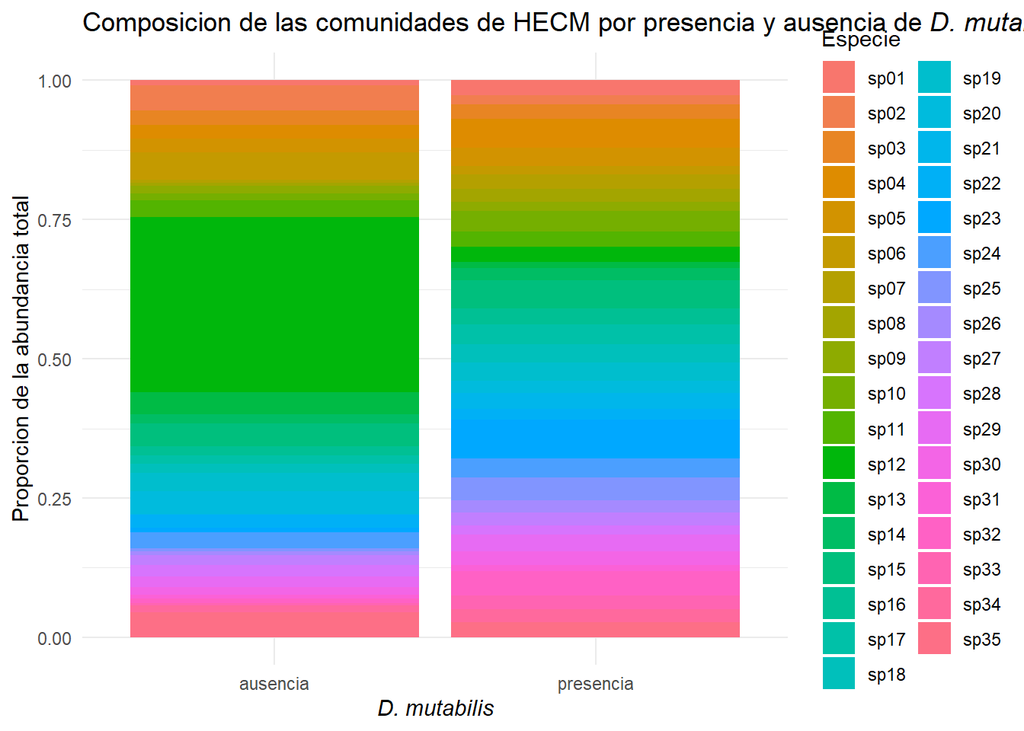

```r
#Examinar composición promedio de las comunidades mediante un stacked barplot
library(ggplot2)
library(dplyr)
library(tidyr)

hecm_with_groups <- df_wide %>%
  dplyr::select(D_mutabilis, starts_with("sp"))

species_cols <- names(hecm_with_groups)[names(hecm_with_groups) != "D_mutabilis"]

group_composition <- hecm_with_groups %>%
  group_by(D_mutabilis) %>%
  summarise(across(all_of(species_cols), sum), .groups = "drop") %>%
  pivot_longer(cols = -D_mutabilis, names_to = "Species", values_to = "Abundance")

Stacked_bar <- ggplot(group_composition, aes(x = D_mutabilis, y = Abundance, fill = Species)) +
  geom_bar(stat = "identity", position = "fill") +
  labs(
    title = expression("Composicion de las comunidades de HECM por presencia y ausencia de " * italic("D. mutabilis")),
    x = expression(italic("D. mutabilis")),
    y = "Proporcion de la abundancia total",
    fill = "Especie"
  ) +
  theme_minimal() +
  theme(
    legend.position = "right"
  )

print(Stacked_bar)
```

```r
ggsave(
  filename = "stacked_bar_hecm.png",
  plot = Stacked_bar,
  width = 10,
  height = 6,
  dpi = 300
)
```

Los datos aparentan presentar una distribución con bastantes 0s y, por consiguiente, especies raras. Entonces, dado que nos interesa comparar el efecto de la presencia de *D. mutabilis* sobre las comunidades de HECM, un análisis de tipo GLM mediante el paquete **mvabund** resulta apropiado. A continuación, cumplimos los requisitos para este análisis evaluando los supuestos necesarios.

# 4. Evaluación de supuestos y distribución

```r
library(vegan)
library(mvabund)
library(ggplot2)
library(dplyr)
library(tidyr)
library(corrplot)
```

```r
#PREPARACIÓN DE LOS DATOS

# Convertir a factor
df_wide$D_mutabilis <- as.factor(df_wide$D_mutabilis)

# Extraer solo las columnas de especies (sp01 a sp35)
hecm_species <- df_wide[, grep("^sp", names(df_wide))]

# Filtrar especies con abundancia total > 0 (eliminar ASVs con 0 reads en todas las muestras)
hecm_species <- hecm_species[, colSums(hecm_species) > 0]

# Convertir a objeto mvabund para manyglm
library(mvabund)
hecm_mv <- mvabund(hecm_species)

cat("Numero de especies filtradas:", ncol(hecm_species), "\n")
```

```
## Numero de especies filtradas: 35
```

```r
cat("Numero de muestras:", nrow(hecm_species), "\n")
```

```
## Numero de muestras: 40
```

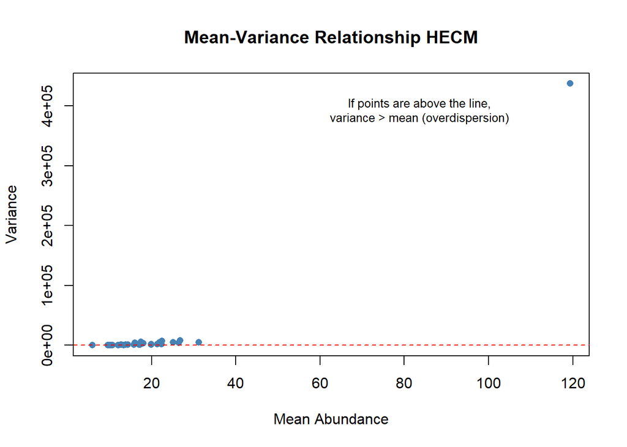

```r
#RELACIÓN MEDIA-VARIANZA PARA EVALUAR SI EXISTE SOBREDISPERSIÓN

species_means <- colMeans(hecm_species)
species_vars <- apply(hecm_species, 2, var)

plot(species_means, species_vars,
     pch = 16, col = "steelblue",
     xlab = "Mean Abundance",
     ylab = "Variance",
     main = "Mean-Variance Relationship HECM")
abline(a = 0, b = 1, col = "red", lty = 2)
text(max(species_means)*0.7, max(species_vars)*0.9,
     "If points are above the line,\nvariance > mean (overdispersion)",
     cex = 0.8)
```

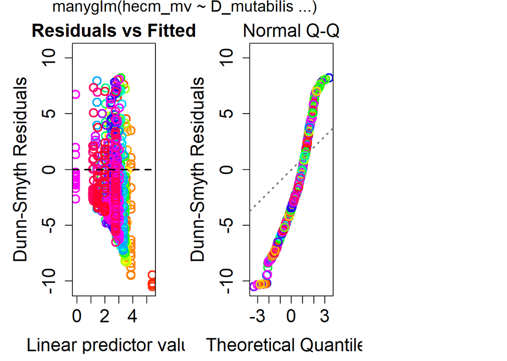

```r
# EVALUACIÓN DE TIPO DE DISTRIBUCIÓN: POISSON VS BINOMIAL NEGATIVA

# Modelo con distribución de Poisson
mod_poisson <- manyglm(hecm_mv ~ D_mutabilis, family = "poisson")

# Modelo con distribución Binomial Negativa
mod_negbin <- manyglm(hecm_mv ~ D_mutabilis, family = "negative.binomial")

# Plot de residuales para distribución de Poisson
par(mfrow = c(2, 2))
distr_pois <- plot(mod_poisson, which = 1:2)
```

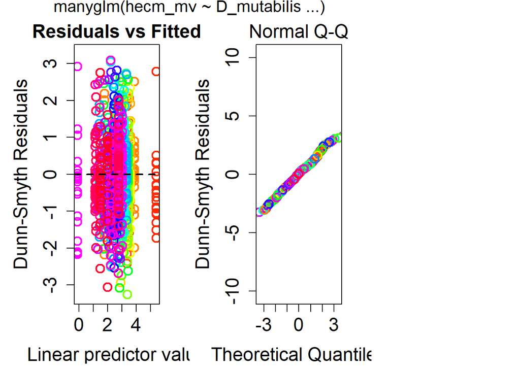

```r
# Plot de residuales para distribución Binomial Negativa
par(mfrow = c(2, 2))
distr_nb <- plot(mod_negbin, which = 1:2)
```

```r
par(mfrow = c(1, 1))
```

De acuerdo con los resultados del análisis de la relación media-varianza y las pruebas de tipos de distribución, los datos presentan sobredispersión y una distribución de tipo bionomial negativa. Considerando esta información, podemos continuar con la construcción del modelo final. Dado que nuestra variable de interés es solo la presencia/ausencia de *D. mutabilis*, solo se incorporará como predictor la presencia/asuencia de *D. mutabilis*.

# 5. Construcción del modelo final

```r
# MODELO FINAL

mv_model <- manyglm(hecm_mv ~ D_mutabilis,
                    data = df_wide,
                    family = "negative.binomial")

# ANOVA con tests ajustados y bootstrapping
cat("\n=== ANOVA (manyglm) ===\n")
```

```
##
## === ANOVA (manyglm) ===
```

```r
anova_result <- anova(mv_model, p.uni = "adjusted", nBoot = 999, test = "LR")
```

```
## Time elapsed: 0 hr 0 min 50 sec
```

```r
print(anova_result)
```

```
## Analysis of Deviance Table
##
## Model: hecm_mv ~ D_mutabilis
##
## Multivariate test:
##             Res.Df Df.diff   Dev Pr(>Dev)
## (Intercept)     39
## D_mutabilis     38       1 80.16    0.017 *
## ---
## Signif. codes:  0 '***' 0.001 '**' 0.01 '*' 0.05 '.' 0.1 ' ' 1
##
## Univariate Tests:
##              sp01           sp02           sp03           sp04           sp05
##               Dev Pr(>Dev)   Dev Pr(>Dev)   Dev Pr(>Dev)   Dev Pr(>Dev)   Dev
## (Intercept)
## D_mutabilis 2.903    0.963 1.462    0.998 0.012    1.000 0.733    1.000 0.139
##                      sp06           sp07          sp08           sp09
##             Pr(>Dev)  Dev Pr(>Dev)   Dev Pr(>Dev)  Dev Pr(>Dev)   Dev Pr(>Dev)
## (Intercept)
## D_mutabilis    1.000 1.64    0.998 4.496    0.795 6.25    0.614 0.106    1.000
##              sp10           sp11           sp12          sp13           sp14
##               Dev Pr(>Dev)   Dev Pr(>Dev)   Dev Pr(>Dev)  Dev Pr(>Dev)   Dev
## (Intercept)
## D_mutabilis 2.043    0.989 0.006    1.000 7.371    0.614 2.41    0.988 0.137
##                       sp15          sp16           sp17          sp18
##             Pr(>Dev)   Dev Pr(>Dev)  Dev Pr(>Dev)   Dev Pr(>Dev)  Dev Pr(>Dev)
## (Intercept)
## D_mutabilis    1.000 0.042    1.000 0.55    1.000 1.152    0.999 0.88    1.000
##              sp19           sp20            sp21           sp22           sp23
##               Dev Pr(>Dev)   Dev Pr(>Dev)    Dev Pr(>Dev)   Dev Pr(>Dev)   Dev
## (Intercept)
## D_mutabilis 0.001    1.000 0.674    1.000 16.684    0.013 0.121    1.000 7.506
##                       sp24           sp25           sp26           sp27
##             Pr(>Dev)   Dev Pr(>Dev)   Dev Pr(>Dev)   Dev Pr(>Dev)   Dev
## (Intercept)
## D_mutabilis    0.604 0.042    1.000 6.245    0.614 4.035    0.858 0.103
##                       sp28           sp29           sp30           sp31
##             Pr(>Dev)   Dev Pr(>Dev)   Dev Pr(>Dev)   Dev Pr(>Dev)   Dev
## (Intercept)
## D_mutabilis    1.000 0.103    1.000 0.343    1.000 0.499    1.000 0.733
##                       sp32           sp33           sp34           sp35
##             Pr(>Dev)   Dev Pr(>Dev)   Dev Pr(>Dev)   Dev Pr(>Dev)   Dev
## (Intercept)
## D_mutabilis    1.000 5.574    0.614 3.816    0.879 0.933    1.000 0.415
##
##             Pr(>Dev)
## (Intercept)
## D_mutabilis    1.000
## Arguments:
##  Test statistics calculated assuming uncorrelated response (for faster computation)
## P-value calculated using 999 iterations via PIT-trap resampling.
```

```r
cat("\n=== COEFICIENTES DEL MODELO ===\n")
```

```
##
## === COEFICIENTES DEL MODELO ===
```

```r
print(mv_model)
```

```
##
## Call:  manyglm(formula = hecm_mv ~ D_mutabilis, family = "negative.binomial",      data = df_wide)
## [1] "negative.binomial"
##
## Nuisance Parameter(s) phi estimated by the PHI method.
##  sp01   sp02   sp03   sp04   sp05   sp06   sp07   sp08   sp09   sp10   sp11
## 3.477  6.176  3.523  7.153  5.675  8.754  4.275  3.095  3.337  4.312  4.846
##  sp12   sp13   sp14   sp15   sp16   sp17   sp18   sp19   sp20   sp21   sp22
## 6.280  5.768  4.265  6.247  5.427  5.465  4.773  5.406  6.535  2.867  6.198
##  sp23   sp24   sp25   sp26   sp27   sp28   sp29   sp30   sp31   sp32   sp33
## 4.401  6.180  4.428  3.506  3.921  4.390  4.372  5.436  3.612  4.137  5.730
##  sp34   sp35
## 4.631  6.716
##
## Degrees of Freedom: 39 Total (i.e. Null); 38 Residual
##
##                     sp01     sp02     sp03     sp04     sp05     sp06
## 2*log-likelihood:   -244.82  -243.36  -274.64  -244.86  -255.57  -214.74
## Residual Deviance:    41.45    37.54    43.91    36.31    37.89    32.20
## AIC:                 250.82   249.36   280.64   250.86   261.57   220.74
##                     sp07     sp08     sp09     sp10     sp11     sp12
## 2*log-likelihood:   -219.70  -226.24  -240.38  -254.20  -261.78  -297.60
## Residual Deviance:    37.92    40.78    42.64    41.03    41.01    43.40
## AIC:                 225.70   232.24   246.38   260.20   267.78   303.60
##                     sp13     sp14     sp15     sp16     sp17     sp18
## 2*log-likelihood:   -225.45  -248.21  -270.29  -241.41  -238.22  -252.61
## Residual Deviance:    38.41    40.28    38.93    37.83    38.77    40.00
## AIC:                 231.45   254.21   276.29   247.41   244.22   258.61
##                     sp19     sp20     sp21     sp22     sp23     sp24
## 2*log-likelihood:   -261.54  -238.84  -201.25  -225.11  -259.96  -249.84
## Residual Deviance:    39.88    37.50    37.84    36.38    41.04    37.61
## AIC:                 267.54   244.84   207.25   231.11   265.96   255.84
##                     sp25     sp26     sp27     sp28     sp29     sp30
## 2*log-likelihood:   -230.47  -226.95  -252.44  -239.05  -257.71  -225.94
## Residual Deviance:    39.78    40.77    42.01    40.82    41.84    37.53
## AIC:                 236.47   232.95   258.44   245.05   263.71   231.94
##                     sp31     sp32     sp33     sp34     sp35
## 2*log-likelihood:   -201.94  -247.60  -195.55  -233.44  -246.86
## Residual Deviance:    39.04    40.94    34.05    38.95    37.49
## AIC:                 207.94   253.60   201.55   239.44   252.86
```

```r
summary(mv_model)
```

```
##
## Test statistics:
##                      wald value Pr(>wald)
## (Intercept)               30.05     0.001 ***
## D_mutabilispresencia      10.17     0.005 **
## ---
## Signif. codes:  0 '***' 0.001 '**' 0.01 '*' 0.05 '.' 0.1 ' ' 1
##
## Test statistic:  10.17, p-value: 0.005
## Arguments:
##  Test statistics calculated assuming response assumed to be uncorrelated
##  P-value calculated using 999 resampling iterations via pit.trap resampling (to account for correlation in testing).
```

La presencia de *D. mutabilis* tiene un efecto significativo sobre la composición de las comunidades de HECM, tanto a nivel global del modelo (test de razón de verosimilitud, Dev = 80.16, p = 0.017) como a nivel del coeficiente asociado al predictor (test de Wald, estadístico = 10.17, p = 0.005), lo que confirma la robustez del resultado. Ahora evaluamos cómo este efecto se expresa sobre la diversidad.

# 6. Representación gráfica de los datos para visualizar lo que se ha probado estadísticamente utilizando una herramienta visual multivariada

Ahora, para garantizar la robustez de nuestra apreciación de los resultados, graficamos usando una herramienta visual multivariada.

```r
library(vegan)
library(ggplot2)
library(dplyr)

# Crear matriz de abundancia: especies
# Columnas de especies: sp01-sp35 (grep("^sp", names(df_wide)))
ecm_species <- df_wide[, grep("^sp", names(df_wide))]

# Crear matriz ambiental: presencia/asuencia de D_mutabilis
env_data <- data.frame(
  D_mutabilis = df_wide$D_mutabilis
)

# Convertir a factor
env_data$D_mutabilis <- as.factor(env_data$D_mutabilis)

# Distancia Bray-Curtis (appropriada para datos de abundancia)
ecm.dist <- vegdist(ecm_species, method = "bray")

# NMDS con metaMDS (auto-rarefaction y múltiples intentos)
ecm.mds <- metaMDS(ecm.dist, distance = "bray", trymax = 100)
```

```
## *** Best solution was not repeated -- monoMDS stopping criteria:
##      8: no. of iterations >= maxit
##     92: stress ratio > sratmax
```

```r
# Ver resultado
print(ecm.mds)
```

```
##
## Call:
## metaMDS(comm = ecm.dist, distance = "bray", trymax = 100)
##
## global Multidimensional Scaling using monoMDS
##
## Data:     ecm.dist
## Distance: bray
##
## Dimensions: 2
## Stress:     0.2609966
## Stress type 1, weak ties
## Best solution was not repeated after 100 tries
## The best solution was from try 76 (random start)
## Scaling: centring, PC rotation, halfchange scaling
## Species: scores missing
```

```r
# Extraer scores de NMDS
ecm.scores <- as.data.frame(scores(ecm.mds))
ecm.scores$site <- rownames(ecm.scores)
ecm.scores$D_mutabilis <- env_data$D_mutabilis

# Ver scores
print(head(ecm.scores))
```

```
##          NMDS1       NMDS2 site D_mutabilis
## 1 -0.220329917  0.14688458    1   presencia
## 2  0.003646648 -0.02658251    2   presencia
## 3 -0.355052019  0.03659143    3   presencia
## 4  0.230133528 -0.11531911    4   presencia
## 5  0.097902304  0.06242729    5   presencia
## 6  0.048954108 -0.24715155    6   presencia
```

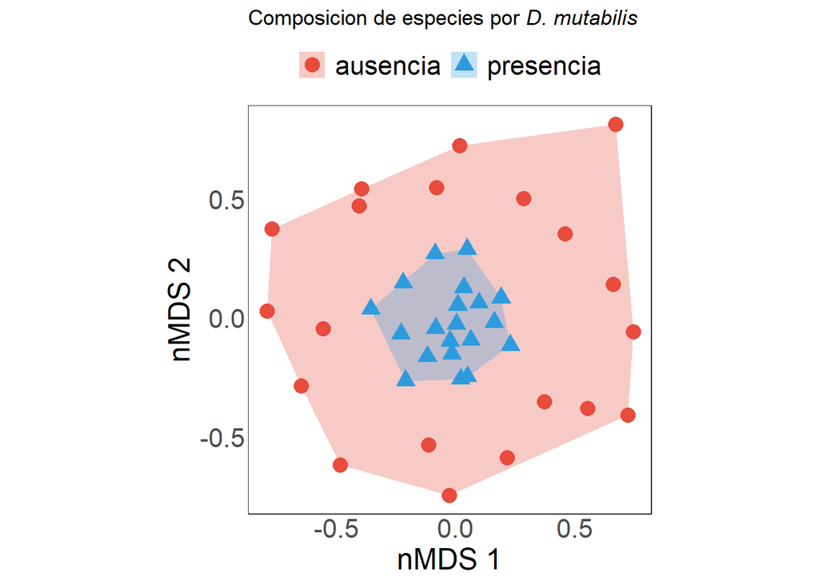

```r
# Convex hull para "ausencia"
grp.ausencia <- ecm.scores[ecm.scores$D_mutabilis == "ausencia", ][
  chull(ecm.scores[ecm.scores$D_mutabilis == "ausencia", c("NMDS1", "NMDS2")]), ]

# Convex hull para "presencia"
grp.presencia <- ecm.scores[ecm.scores$D_mutabilis == "presencia", ][
  chull(ecm.scores[ecm.scores$D_mutabilis == "presencia", c("NMDS1", "NMDS2")]), ]

# Combine hulls
hull.groups <- rbind(grp.ausencia, grp.presencia)

# Plot: NMDS según presencia/ausencia de D. mutabilis
p_nmds <- ggplot() +
  # Polygon (convex hull)
  geom_polygon(data = hull.groups,
               aes(x = NMDS1, y = NMDS2, fill = D_mutabilis, group = D_mutabilis),
               alpha = 0.30) +
  # Points
  geom_point(data = ecm.scores,
             aes(x = NMDS1, y = NMDS2, shape = D_mutabilis, colour = D_mutabilis),
             size = 4) +
  # Coordenadas iguales
  coord_equal() +
  # Theme
  theme_bw() +
  labs(
    x = "nMDS 1",
    y = "nMDS 2",
    title = expression("Composicion de especies por " * italic("D. mutabilis")),
    colour = expression(italic("D. mutabilis")),
    shape = expression(italic("D. mutabilis")),
    fill = expression(italic("D. mutabilis"))
  ) +
  # Color manual
  scale_colour_manual(values = c("ausencia" = "#E74C3C", "presencia" = "#2E9BDF")) +
  scale_fill_manual(values = c("ausencia" = "#E74C3C", "presencia" = "#2E9BDF")) +
  scale_shape_manual(values = c("ausencia" = 16, "presencia" = 17)) +
  # Theme detallado
  theme(
    axis.text.x = element_text(size = 16),
    axis.text.y = element_text(size = 16),
    axis.ticks = element_blank(),
    axis.title.x = element_text(size = 18),
    axis.title.y = element_text(size = 18),
    panel.background = element_blank(),
    panel.grid.major = element_blank(),
    panel.grid.minor = element_blank(),
    plot.background = element_blank(),
    legend.title = element_blank(),
    legend.text = element_text(size = 16),
    legend.position = "top"
  )

print(p_nmds)
```

```r
# Exportar
ggsave("nmds_by_muerdago.png", p_nmds, width = 10, height = 8, dpi = 300)
print("Plot exportado como 'nmds_by_muerdago.png'")
```

```
## [1] "Plot exportado como 'nmds_by_muerdago.png'"
```

```r
#  Valor de estrés
print(paste0("Stress: ", ecm.mds$stress))
```

```
## [1] "Stress: 0.260996582613771"
```

# 7. Cálculo de métricas de diversidad alfa

```r
library(vegan)
library(dplyr)
library(tidyr)
library(ggplot2)

# 1. CALCULAR MÉTRICAS DE DIVERSIDAD ALFA

# Matriz de abundancia: df_wide (solo columnas de especies sp01-sp35)
ecm_species <- df_wide[, grep("^sp", names(df_wide))]

# Cálculo de métricas de diversidad alfa
alpha <- data.frame(
  D_mutabilis = df_wide$D_mutabilis,  # Variable (presencia/ausencia de D. mutabilis)
  richness  = specnumber(ecm_species),  # Riqueza (S)(n especies con count > 0)
  shannon   = diversity(ecm_species, index = "shannon"),  # Shannon (H')
  evenness  = diversity(ecm_species, index = "shannon") / log(specnumber(ecm_species))  # Pielou (J')
)

print("=== DIVERSIDAD ALFA POR MUESTRA ===")
```

```
## [1] "=== DIVERSIDAD ALFA POR MUESTRA ==="
```

```r
print(alpha)
```

```
##    D_mutabilis richness   shannon  evenness
## 1    presencia       22 2.5604245 0.8283369
## 2    presencia       29 2.8518204 0.8469171
## 3    presencia       27 2.1256868 0.6449612
## 4    presencia       25 2.4485721 0.7606917
## 5    presencia       30 2.6663449 0.7839430
## 6    presencia       30 2.7945833 0.8216469
## 7    presencia       25 2.2913853 0.7118589
## 8    presencia       24 2.7455477 0.8639085
## 9    presencia       30 3.0204414 0.8880524
## 10   presencia       25 2.7761049 0.8624455
## 11   presencia       29 3.0509154 0.9060432
## 12   presencia       29 2.7115619 0.8052639
## 13   presencia       29 2.4622129 0.7312137
## 14   presencia       30 2.7911675 0.8206426
```

[output cut: 26 more lines]

```r
# 2. RESUMIR

alpha_summary <- alpha %>%
  group_by(D_mutabilis) %>%  # Variable (presencia/ausencia de D. mutabilis)
  summarise(
    mean_S  = mean(richness),  sd_S  = sd(richness),
    mean_H  = mean(shannon),   sd_H  = sd(shannon),
    mean_J  = mean(evenness),  sd_J  = sd(evenness),
    n = n(),
    .groups = "drop"
  )

print(alpha_summary)
```

```
## # A tibble: 2 × 8
##   D_mutabilis mean_S  sd_S mean_H  sd_H mean_J   sd_J     n
##   <fct>        <dbl> <dbl>  <dbl> <dbl>  <dbl>  <dbl> <int>
## 1 ausencia      12.2  2.52   1.49 0.362  0.605 0.134     20
## 2 presencia     27.1  2.51   2.63 0.282  0.798 0.0834    20
```

# 8. Construcción de modelos GLM y evaluación de supuestos sobre los residuales para métricas de diversidad alfa

Para comparar de manera estadísticamente válida las métricas de diversidad alfa entre las muestras con y sin presencia de *D. mutabilis*, se ajustan modelos GLM específicos para cada métrica. La distribución de errores se selecciona en función de la naturaleza de cada variable (conteos para riqueza, valores continuos para Shannon, proporciones para evenness) y se compara mediante AIC cuando existe más de una distribución candidata. Una vez construido cada modelo, los supuestos (distribución de los residuales, dispersión, presencia de outliers) se evalúan sobre los residuales simulados del modelo mediante el paquete **DHARMa**.

```r
# GLMs para Riqueza, Shannon y Evenness

library(MASS)      # glm.nb
library(DHARMa)
library(glmmTMB)   # para evenness (beta), compatible con DHARMa

# Riqueza (S)
# Al tratarse de datos de conteo, probamos y comparamos modelos con dos posibles distribuciones (Poisson o Bionmial negativa)
glm_S_pois <- glm(richness ~ D_mutabilis, data = alpha, family = poisson)
glm_S_nb   <- glm.nb(richness ~ D_mutabilis, data = alpha)

AIC(glm_S_pois, glm_S_nb)
```

```
##            df      AIC
## glm_S_pois  2 208.1251
## glm_S_nb    3 210.1258
```

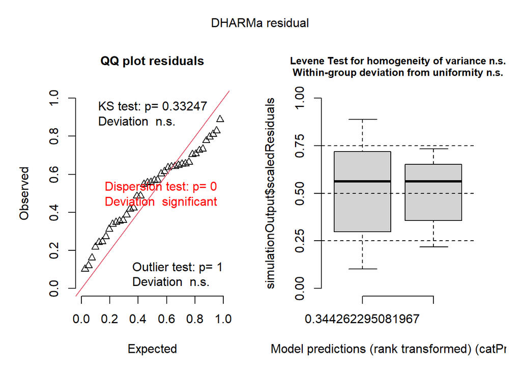

```r
# Validación del modelo con menor AIC: glm_S_pois
sim_S <- simulateResiduals(glm_S_pois, plot = TRUE)
```

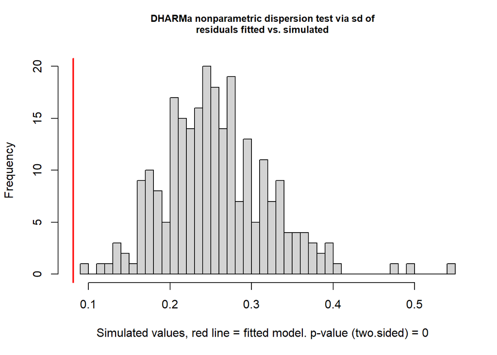

```
##
##  DHARMa nonparametric dispersion test via sd of residuals fitted vs.
##  simulated
##
## data:  simulationOutput
## dispersion = 0.31641, p-value < 2.2e-16
## alternative hypothesis: two.sided
```

```r
testDispersion(sim_S)
```

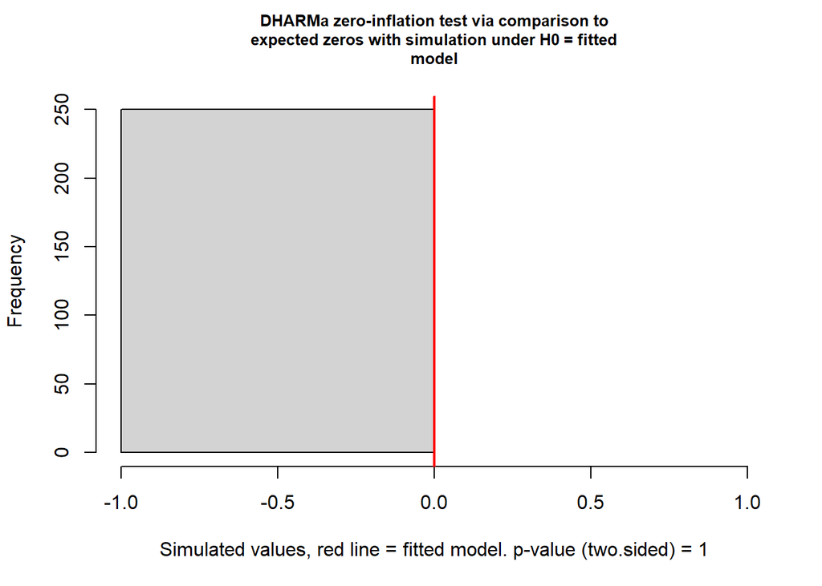

```
##
##  DHARMa zero-inflation test via comparison to expected zeros with
##  simulation under H0 = fitted model
##
## data:  simulationOutput
## ratioObsSim = NaN, p-value = 1
## alternative hypothesis: two.sided
```

```r
testZeroInflation(sim_S)
```

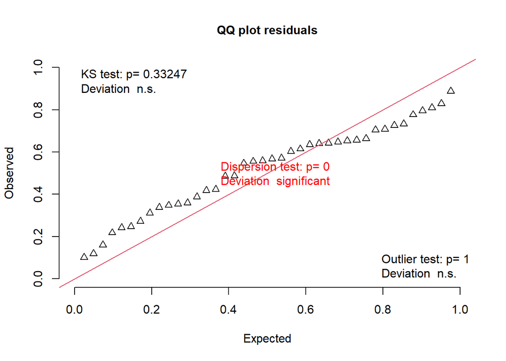

```
##
##  Exact one-sample Kolmogorov-Smirnov test
##
## data:  simulationOutput$scaledResiduals
## D = 0.14552, p-value = 0.3325
## alternative hypothesis: two-sided
```

```r
testUniformity(sim_S)
```

```r
summary(glm_S_pois)
```

```
##
## Call:
## glm(formula = richness ~ D_mutabilis, family = poisson, data = alpha)
##
## Coefficients:
##                      Estimate Std. Error z value Pr(>|z|)
## (Intercept)           2.49733    0.06415   38.93   <2e-16 ***
## D_mutabilispresencia  0.80220    0.07720   10.39   <2e-16 ***
## ---
## Signif. codes:  0 '***' 0.001 '**' 0.01 '*' 0.05 '.' 0.1 ' ' 1
##
## (Dispersion parameter for poisson family taken to be 1)
##
##     Null deviance: 131.609  on 39  degrees of freedom
## Residual deviance:  14.795  on 38  degrees of freedom
## AIC: 208.13
##
## Number of Fisher Scoring iterations: 4
```

```r
# Shannon (H)
#Los valores de H son datos continuos y positivos, por lo que su distribución podría en teoría ser tanto gamma como gaussiana.
glm_H_gaus  <- glm(shannon ~ D_mutabilis, data = alpha, family = gaussian)
glm_H_gamma <- glm(shannon ~ D_mutabilis, data = alpha, family = Gamma(link = "log"))

AIC(glm_H_gaus, glm_H_gamma)
```

```
##             df      AIC
## glm_H_gaus   3 27.38844
## glm_H_gamma  3 50.15278
```

```r
range(alpha$shannon)  # chequear que no haya ceros si se elige Gamma (soporte estrictamente positivo)
```

```
## [1] 0.4453668 3.0509154
```

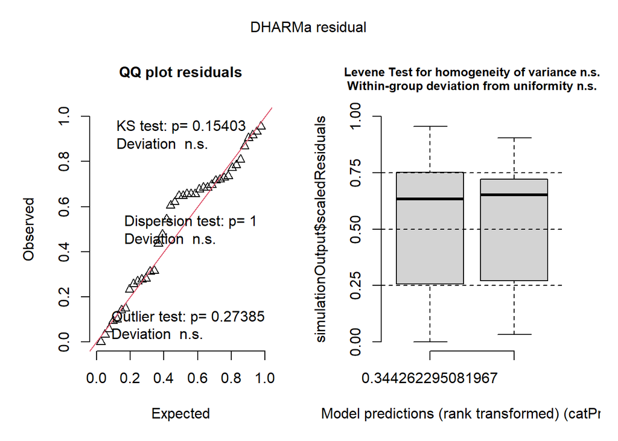

```r
# Validación del modelo con menor AIC: glm_H_gaus
sim_H <- simulateResiduals(glm_H_gaus, plot = TRUE)
```

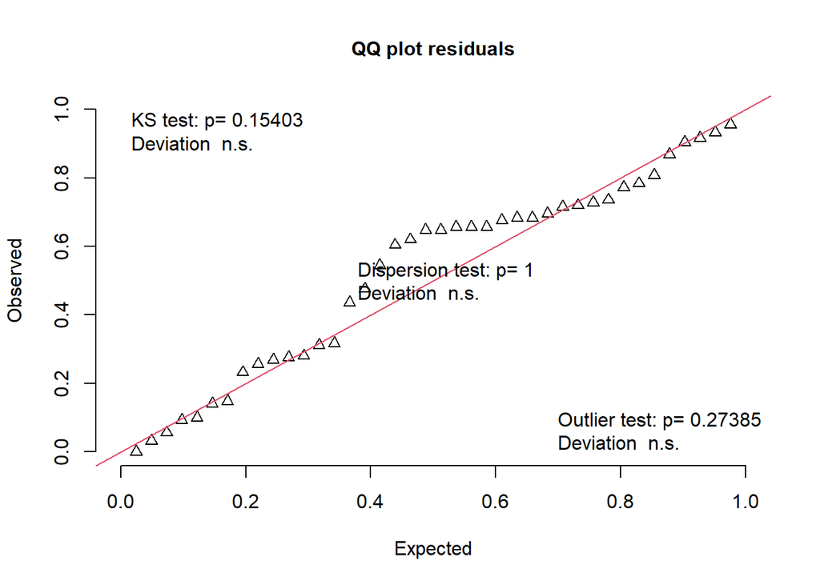

```
##
##  Asymptotic one-sample Kolmogorov-Smirnov test
##
## data:  simulationOutput$scaledResiduals
## D = 0.179, p-value = 0.154
## alternative hypothesis: two-sided
```

```r
testUniformity(sim_H)
```

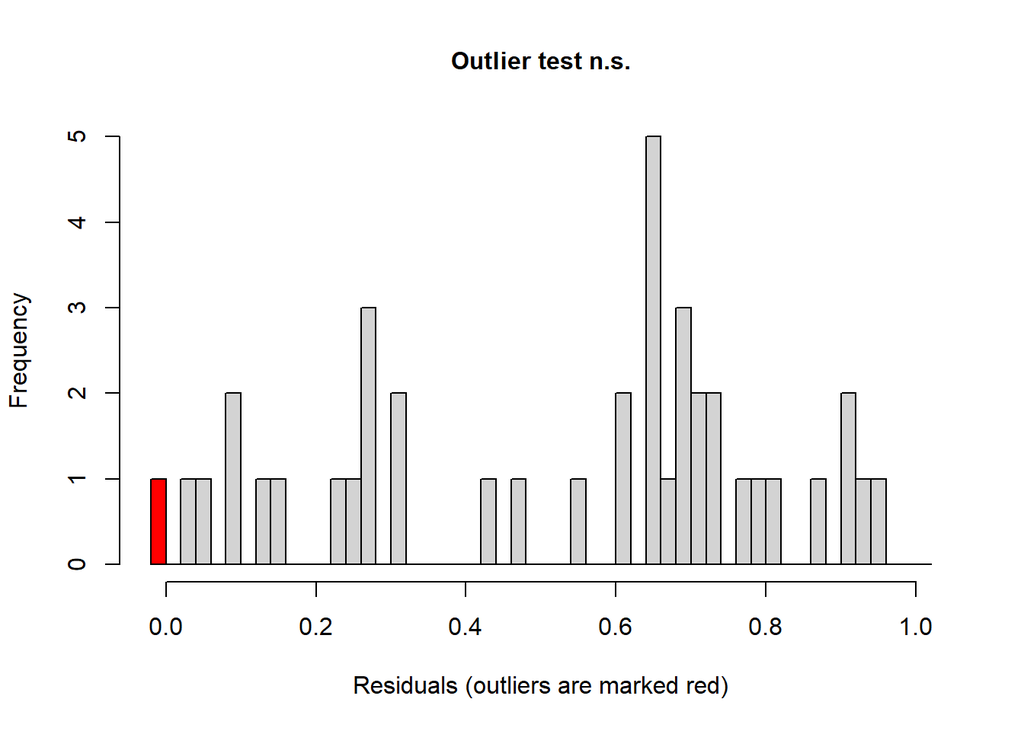

```
##
##  DHARMa outlier test based on exact binomial test with approximate
##  expectations
##
## data:  sim_H
## outliers at both margin(s) = 1, observations = 40, p-value = 0.2739
## alternative hypothesis: true probability of success is not equal to 0.007968127
## 95 percent confidence interval:
##  0.0006327449 0.1315858585
## sample estimates:
## frequency of outliers (expected: 0.00796812749003984 )
##                                                  0.025
```

```r
testOutliers(sim_H)
```

```r
summary(glm_H_gaus)
```

```
##
## Call:
## glm(formula = shannon ~ D_mutabilis, family = gaussian, data = alpha)
##
## Coefficients:
##                      Estimate Std. Error t value Pr(>|t|)
## (Intercept)           1.49444    0.07253   20.61  < 2e-16 ***
## D_mutabilispresencia  1.13506    0.10257   11.07  1.9e-13 ***
## ---
## Signif. codes:  0 '***' 0.001 '**' 0.01 '*' 0.05 '.' 0.1 ' ' 1
##
## (Dispersion parameter for gaussian family taken to be 0.105202)
##
##     Null deviance: 16.8813  on 39  degrees of freedom
## Residual deviance:  3.9977  on 38  degrees of freedom
## AIC: 27.388
##
## Number of Fisher Scoring iterations: 2
```

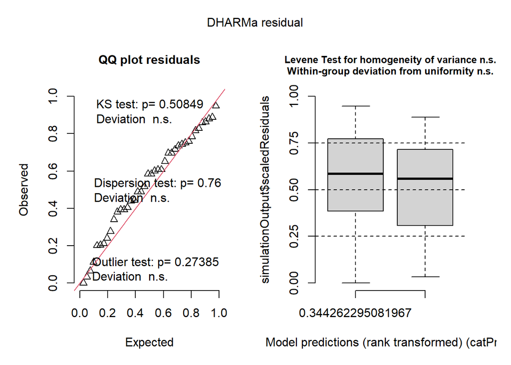

```r
# Evenness (J)
# Evenness solo puede tomar valores estrictamente entre 0 y 1, por lo que la distribución es de tipo Beta. Betareg no es compatible con DHARMa (no es objeto glm) -> se usa glmmTMB con familia Beta.

glm_J <- glmmTMB(evenness ~ D_mutabilis, data = alpha, family = beta_family())

sim_J <- simulateResiduals(glm_J, plot = TRUE)
```

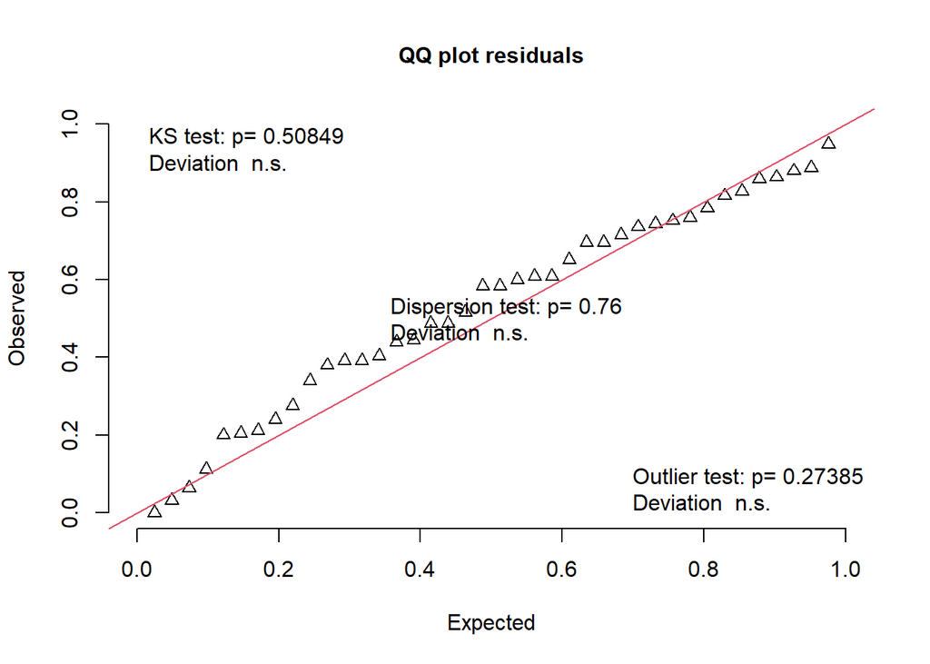

```
##
##  Asymptotic one-sample Kolmogorov-Smirnov test
##
## data:  simulationOutput$scaledResiduals
## D = 0.13, p-value = 0.5085
## alternative hypothesis: two-sided
```

```r
testUniformity(sim_J)
```

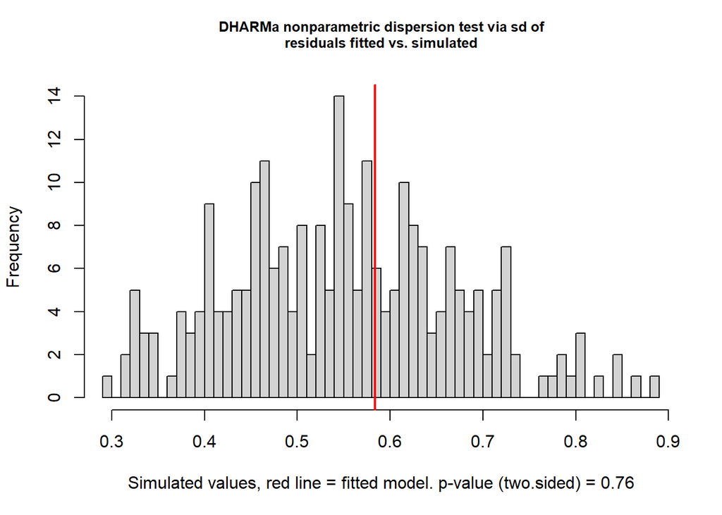

```
##
##  DHARMa nonparametric dispersion test via sd of residuals fitted vs.
##  simulated
##
## data:  simulationOutput
## dispersion = 1.0602, p-value = 0.76
## alternative hypothesis: two.sided
```

```r
testDispersion(sim_J)
```

```r
summary(glm_J)
```

```
##  Family: beta  ( logit )
## Formula:          evenness ~ D_mutabilis
## Data: alpha
##
##       AIC       BIC    logLik -2*log(L)  df.resid
##     -62.7     -57.6      34.4     -68.7        37
##
##
## Dispersion parameter for beta family (): 16.9
##
## Conditional model:
##                      Estimate Std. Error z value Pr(>|z|)
## (Intercept)            0.4062     0.1075   3.777 0.000159 ***
## D_mutabilispresencia   0.9284     0.1663   5.582 2.37e-08 ***
## ---
## Signif. codes:  0 '***' 0.001 '**' 0.01 '*' 0.05 '.' 0.1 ' ' 1
```

# 9. Representación gráfica de métricas de diversidad alfa

Ahora que confirmamos, mediante ambos enfoques, la significancia de las diferencias, graficamos los resultados de las métricas de diversidad alfa para ambos grupos y apreciamos visualmente el efecto de la presencia y ausencia de *D. muatabilis* sobre las comunidades de hecm.

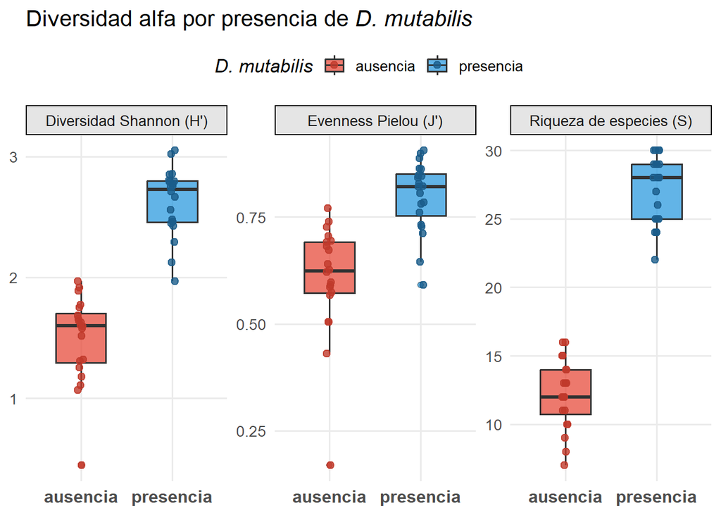

```r
# PLOT
alpha_long <- alpha %>%
  pivot_longer(cols = c(richness, shannon, evenness),
               names_to = "metric", values_to = "value") %>%
  mutate(metric = case_when(
    metric == "richness" ~ "Riqueza de especies (S)",
    metric == "shannon"  ~ "Diversidad Shannon (H')",
    metric == "evenness" ~ "Evenness Pielou (J')"
  ),
         D_mutabilis = factor(D_mutabilis, levels = c("ausencia", "presencia")))

p_alpha <- ggplot(alpha_long,
                  aes(x = D_mutabilis, y = value, fill = D_mutabilis)) +
  geom_boxplot(alpha = 0.75, outlier.shape = 21, width = 0.55,
               position = position_dodge(0.7)) +
  geom_jitter(aes(color = D_mutabilis),
              position = position_jitterdodge(jitter.width = 0.1, dodge.width = 0.7),
              size = 2, alpha = 0.8) +
  scale_fill_manual(values = c("ausencia" = "#E74C3C", "presencia" = "#2E9BDF")) +
  scale_color_manual(values = c("ausencia" = "#C0392B", "presencia" = "#1A5C8A")) +
  facet_wrap(~ metric, scales = "free_y", ncol = 3) +
  labs(
    title = expression("Diversidad alfa por presencia de " * italic("D. mutabilis")),
    x = NULL, y = NULL,
    fill = expression(italic("D. mutabilis")),
    color = expression(italic("D. mutabilis"))
  ) +
  theme_minimal(base_size = 13) +
  theme(
    strip.background = element_rect(fill = "grey90"),
    panel.grid.minor = element_blank(),
    legend.position = "top",
    axis.text.x = element_text(size = 12, face = "bold")
  )

print(p_alpha)
```

```r
# Exportar
ggsave("alpha_diversity_by_muerdago.png", p_alpha, width = 12, height = 6, dpi = 300)
print("Plot exportado como 'alpha_diversity_by_muerdago.png'")
```

```
## [1] "Plot exportado como 'alpha_diversity_by_muerdago.png'"
```